# ft-SNE

### mnist6k

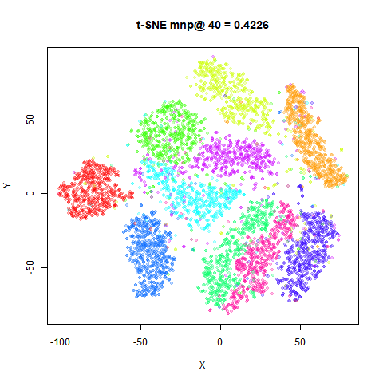

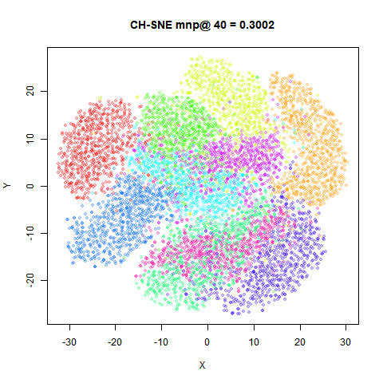

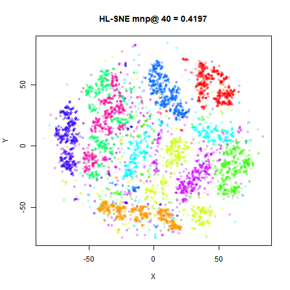

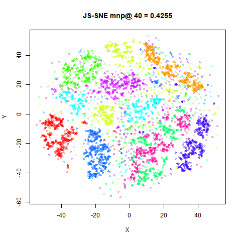

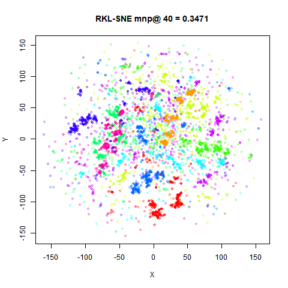

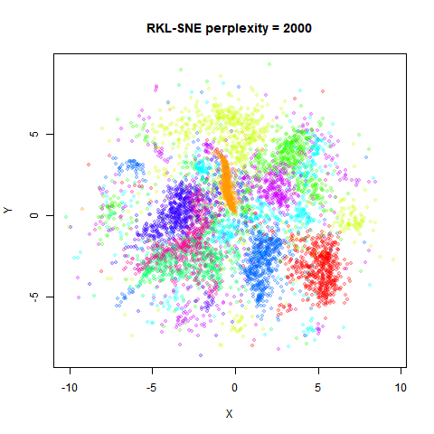

### fashion6k

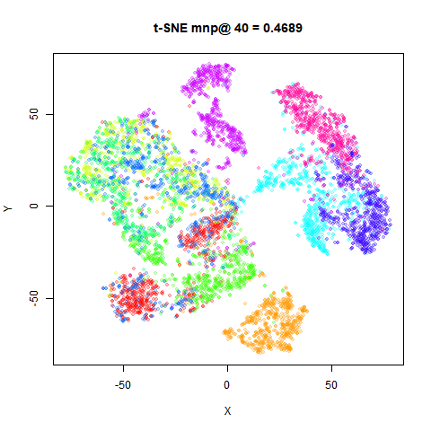

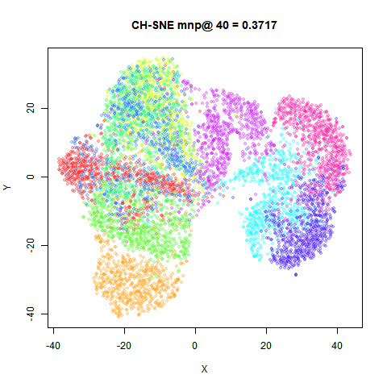

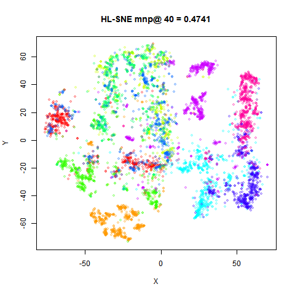

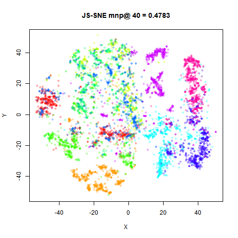

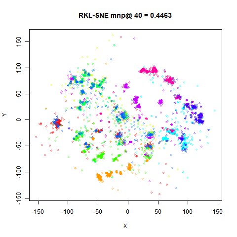

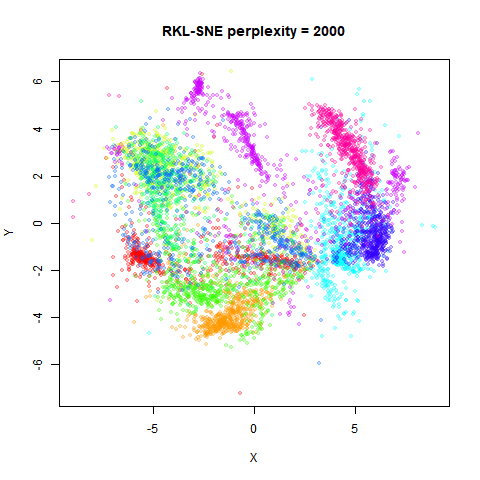

## Conclusions

As seems to be usual whenever alternative to the KL divergence are used in an SNE-like cost function, the resulting plots don’t seem to provide any major benefit over t-SNE. In this case, these divergences seem mostly to provide worse visualizations, and their more complex gradients mean they are less efficient also.

Part of this is because these datasets have historically been used to demonstrate how well t-SNE works, so it’s probably not a huge surprise. As predicted by the ft-SNE paper, the CH-SNE results are in general closest to the t-SNE results, because the $\chi^2$ divergence emphasises local structure like the KL divergence. The CH-SNE results are more spread out, which might be an issue with larger datasets, where the KL divergence already leads to quite diffuse clusters compared to LargeVis and UMAP. For `coil20`, it gives the most interpretable result of all the non-KL divergences.

The HL-SNE and JS-SNE results, which are both classified as balancing global and local structure, are indeed very similar to each other and so seem intermediate between the t-SNE and RKL-SNE results. The effect seems to be to compress the clusters, but also to split them up. I don’t know if I can see a concomitant improvement to the understanding of the global structure that makes up for that. If I had to choose between them, I would go with HL-SNE, as it’s less effort to calculate.

The reverse KL results continue the trend of compressing the clusters and increasing the spread of data. If you ignore the “outlier” points (the existence of which is to be expected due to false positives being penalized greatly), the global structure is well represented. The larger perplexity helps with the visualization. That said, I would think that initializing t-SNE via PCA is still a simpler solution.

I was hoping that the RKL-SNE results may at least represent relative cluster sizes better: where as the orange cluster (the ‘1’ digits) in the t-SNE result is of similar size to the red cluster (the ‘0’ digits), in the RKL-SNE results with high perplexity, the orange cluster is much smaller compared to the red cluster. However this seems to be an effect of using a large perplexity value, as t-SNE embeddings with the same perplexity values also show the difference in cluster sizes. Here are the high-perplexity RKL-SNE results again for `mnist6k` and `fashion6k` on the left, and the equivalent t-SNE results on the right:

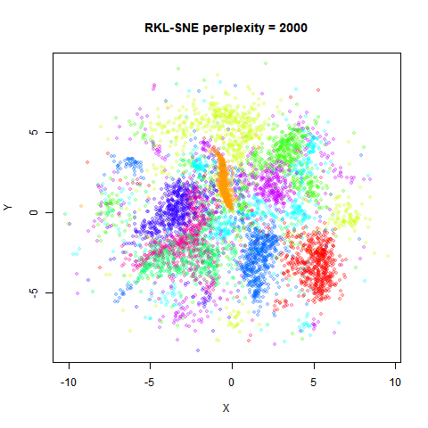

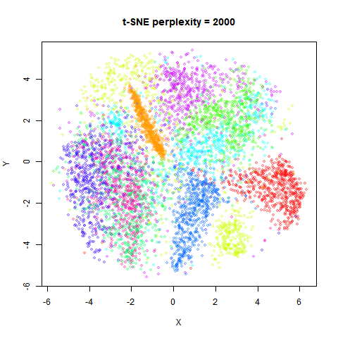

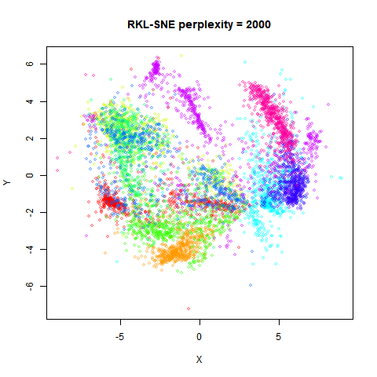

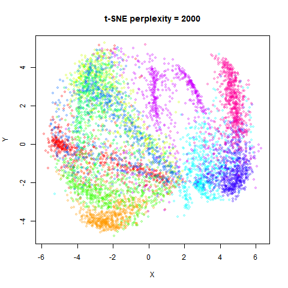

Is initialization an issue with RKL-SNE? The scaled PCA approach certainly works well for the KL divergence, but possibly it’s not a useful method for global structures. To test this, I re-ran RKL-SNE initializing from the usual random t-SNE initialization (the ft-SNE default), from an MMDS solution and from the t-SNE result. What follows are the results for `mnist6k` and `fashion6k` only, because larger datasets are where the initialization really matters (there are some differences for the smaller datasets but not anything that merits producing the figures here). On the first row the left hand image is the spca result (already shown above), and the right hand image is from a random initialization. On the bottom row, the left hand images is an initialization from metric MDS, and the right hand image is from initializing from the t-SNE result, which promotes the sort of configuration that is the opposite of what is optimal for the reverse KL divergence, so we might expect this to be a worst-case scenario. For these images, the final cost is also provided in the image title. A lower value is better.

### mnist6k

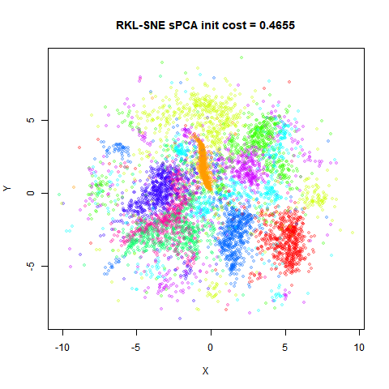

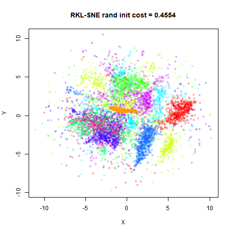

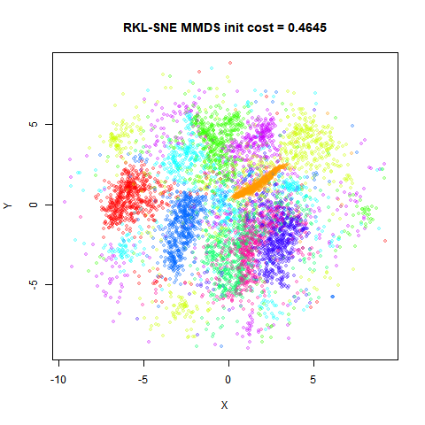

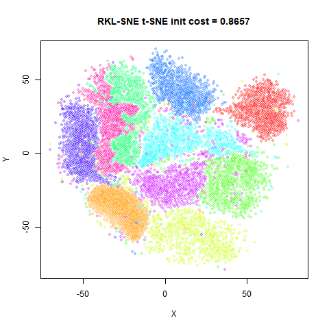

### fashion6k

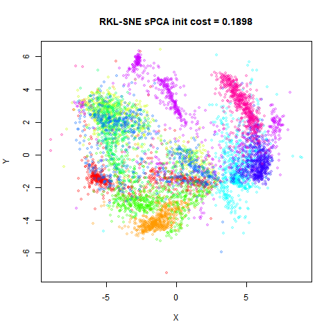

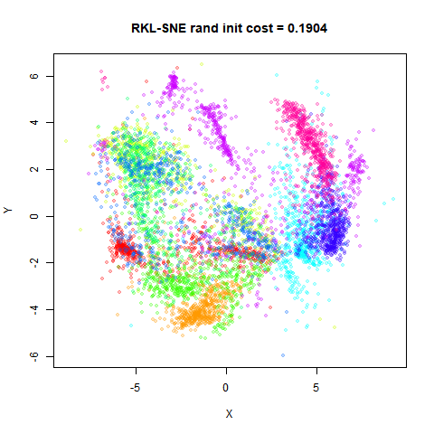

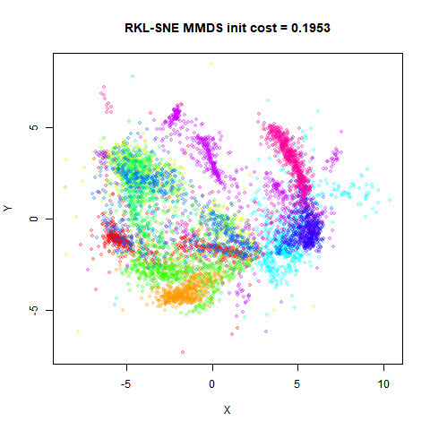

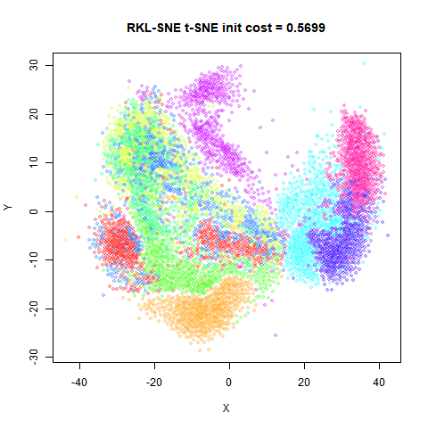

The t-SNE-based initializations are definitely sub-optimal in terms of cost after 1000 iterations. On the other hand, the PCA-based initialization seems pretty competitive with random or MMDS-based initialization. The overall plots end up quite similar, so there doesn’t seem to be a problem with a bad initialization (or all the methods I’ve tried are bad).

I would be interested in finding datasets where divergences other than KL provide interesting visualizations. Unfortunately for the datasets considered here it doesn’t seem that the f-divergences are that useful.

Up: [Documentation Home](https://jlmelville.github.io/smallvis/).